# What Affect White Wine Quality by Francis Tam

In this research, we will use exploratory data analysis techniques to investigate how chemicals and attributes within white wine affect its perceived quality.

This dataset is from P. Cortez, A. Cerdeira, F. Almeida, T. Matos and J. Reis. @2009, Modeling wine preferences by data mining from physicochemical properties. In Decision Support Systems, Elsevier, 47(4):547-553. ISSN: 0167-9236.

Available at:

[@Elsevier] http://dx.doi.org/10.1016/j.dss.2009.05.016

[Pre-press (pdf)] http://www3.dsi.uminho.pt/pcortez/winequality09.pdf

[bib] http://www3.dsi.uminho.pt/pcortez/dss09.bib

# Basic Dataset Information

```
Attribute information:

   For more information, read [Cortez et al., 2009].

   Input variables (based on physicochemical tests):
   1 - fixed acidity (tartaric acid - g / dm^3)
   2 - volatile acidity (acetic acid - g / dm^3)
   3 - citric acid (g / dm^3)
   4 - residual sugar (g / dm^3)
   5 - chlorides (sodium chloride - g / dm^3
   6 - free sulfur dioxide (mg / dm^3)
   7 - total sulfur dioxide (mg / dm^3)
   8 - density (g / cm^3)
   9 - pH
   10 - sulphates (potassium sulphate - g / dm3)
   11 - alcohol (% by volume)
   Output variable (based on sensory data):
   12 - quality (score between 0 and 10)
```

```
Description of attributes:

   1 - fixed acidity: most acids involved with wine or fixed or nonvolatile (do not evaporate readily)
   2 - volatile acidity: the amount of acetic acid in wine, which at too high of levels can lead to an unpleasant, vinegar taste
   3 - citric acid: found in small quantities, citric acid can add 'freshness' and flavor to wines
   4 - residual sugar: the amount of sugar remaining after fermentation stops, it's rare to find wines with less than 1 gram/liter and wines with greater than 45 grams/liter are considered sweet
   5 - chlorides: the amount of salt in the wine
   6 - free sulfur dioxide: the free form of SO2 exists in equilibrium between molecular SO2 (as a dissolved gas) and bisulfite ion; it prevents microbial growth and the oxidation of wine
   7 - total sulfur dioxide: amount of free and bound forms of S02; in low concentrations, SO2 is mostly undetectable in wine, but at free SO2 concentrations over 50 ppm, SO2 becomes evident in the nose and taste of wine
   8 - density: the density of water is close to that of water depending on the percent alcohol and sugar content
   9 - pH: describes how acidic or basic a wine is on a scale from 0 (very acidic) to 14 (very basic); most wines are between 3-4 on the pH scale
   10 - sulphates: a wine additive which can contribute to sulfur dioxide gas (S02) levels, wich acts as an antimicrobial and antioxidant
   11 - alcohol: the percent alcohol content of the wine
   Output variable (based on sensory data):
   12 - quality (score between 0 and 10)
```

```r
str(ww)
```

```
## 'data.frame':    4898 obs. of  13 variables:
##  $ X                   : int  1 2 3 4 5 6 7 8 9 10 ...
##  $ fixed.acidity       : num  7 6.3 8.1 7.2 7.2 8.1 6.2 7 6.3 8.1 ...
##  $ volatile.acidity    : num  0.27 0.3 0.28 0.23 0.23 0.28 0.32 0.27 0.3 0.22 ...
##  $ citric.acid         : num  0.36 0.34 0.4 0.32 0.32 0.4 0.16 0.36 0.34 0.43 ...
##  $ residual.sugar      : num  20.7 1.6 6.9 8.5 8.5 6.9 7 20.7 1.6 1.5 ...
##  $ chlorides           : num  0.045 0.049 0.05 0.058 0.058 0.05 0.045 0.045 0.049 0.044 ...
##  $ free.sulfur.dioxide : num  45 14 30 47 47 30 30 45 14 28 ...
##  $ total.sulfur.dioxide: num  170 132 97 186 186 97 136 170 132 129 ...
##  $ density             : num  1.001 0.994 0.995 0.996 0.996 ...
##  $ pH                  : num  3 3.3 3.26 3.19 3.19 3.26 3.18 3 3.3 3.22 ...
##  $ sulphates           : num  0.45 0.49 0.44 0.4 0.4 0.44 0.47 0.45 0.49 0.45 ...
##  $ alcohol             : num  8.8 9.5 10.1 9.9 9.9 10.1 9.6 8.8 9.5 11 ...
##  $ quality             : int  6 6 6 6 6 6 6 6 6 6 ...
```

```r
summary(ww)
```

```
##        X        fixed.acidity    volatile.acidity  citric.acid
##  Min.   :   1   Min.   : 3.800   Min.   :0.0800   Min.   :0.0000
##  1st Qu.:1225   1st Qu.: 6.300   1st Qu.:0.2100   1st Qu.:0.2700
##  Median :2450   Median : 6.800   Median :0.2600   Median :0.3200
##  Mean   :2450   Mean   : 6.855   Mean   :0.2782   Mean   :0.3342
##  3rd Qu.:3674   3rd Qu.: 7.300   3rd Qu.:0.3200   3rd Qu.:0.3900
##  Max.   :4898   Max.   :14.200   Max.   :1.1000   Max.   :1.6600
##  residual.sugar     chlorides       free.sulfur.dioxide
##  Min.   : 0.600   Min.   :0.00900   Min.   :  2.00
##  1st Qu.: 1.700   1st Qu.:0.03600   1st Qu.: 23.00
##  Median : 5.200   Median :0.04300   Median : 34.00
##  Mean   : 6.391   Mean   :0.04577   Mean   : 35.31
##  3rd Qu.: 9.900   3rd Qu.:0.05000   3rd Qu.: 46.00
##  Max.   :65.800   Max.   :0.34600   Max.   :289.00
##  total.sulfur.dioxide    density             pH          sulphates
##  Min.   :  9.0        Min.   :0.9871   Min.   :2.720   Min.   :0.2200
##  1st Qu.:108.0        1st Qu.:0.9917   1st Qu.:3.090   1st Qu.:0.4100
##  Median :134.0        Median :0.9937   Median :3.180   Median :0.4700
##  Mean   :138.4        Mean   :0.9940   Mean   :3.188   Mean   :0.4898
##  3rd Qu.:167.0        3rd Qu.:0.9961   3rd Qu.:3.280   3rd Qu.:0.5500
##  Max.   :440.0        Max.   :1.0390   Max.   :3.820   Max.   :1.0800
##     alcohol         quality
##  Min.   : 8.00   Min.   :3.000
##  1st Qu.: 9.50   1st Qu.:5.000
##  Median :10.40   Median :6.000
##  Mean   :10.51   Mean   :5.878
##  3rd Qu.:11.40   3rd Qu.:6.000
##  Max.   :14.20   Max.   :9.000
```

```r
table(ww$quality)
```

```
##
##    3    4    5    6    7    8    9
##   20  163 1457 2198  880  175    5
```

So although quality can be assigned 0 to 10, only 3 to 9 were used in scoring.

On the other hand, the other vectors seem to be continuous, except X which is the unique identifier.

Let’s get a general feel about the data in the univariate plots.

# Univariate Plots Section

### Fixed Acidity

```r
summary(ww$fixed.acidity)
```

```
##    Min. 1st Qu.  Median    Mean 3rd Qu.    Max.
##   3.800   6.300   6.800   6.855   7.300  14.200
```

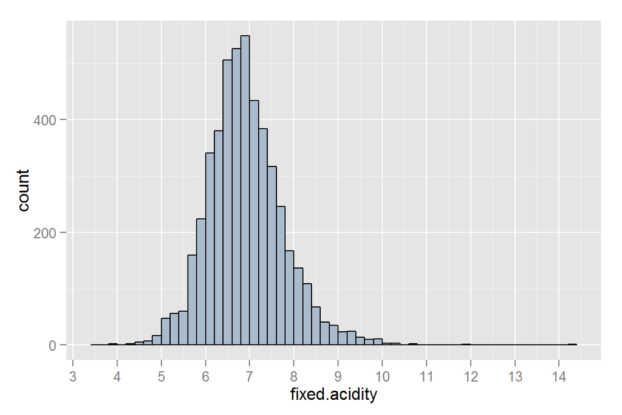

```r
ggplot(aes(fixed.acidity), data=ww) +
  geom_histogram(binwidth=0.2, color='black', fill='#aabbcc') +
  scale_x_continuous(breaks=seq(0, 15, 1))
```

It takes a bell shape.

### Volatile Acidity

```r
summary(ww$volatile.acidity)
```

```
##    Min. 1st Qu.  Median    Mean 3rd Qu.    Max.
##  0.0800  0.2100  0.2600  0.2782  0.3200  1.1000
```

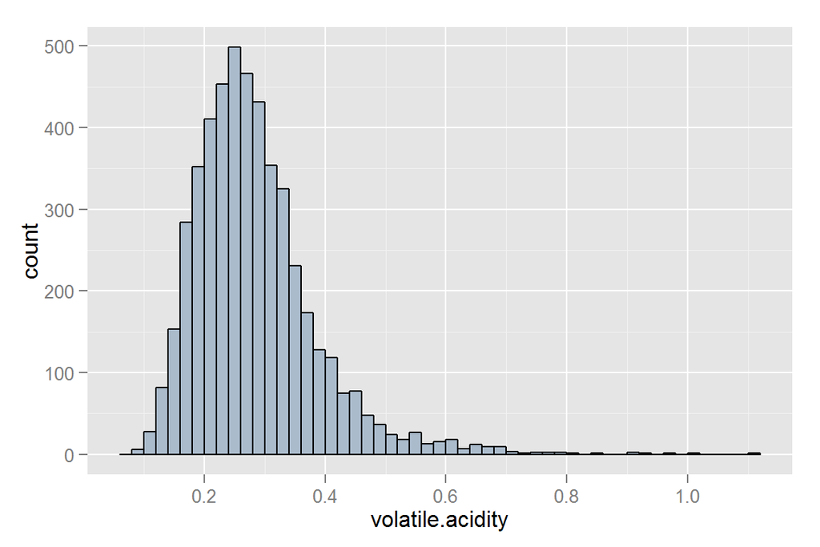

```r
ggplot(aes(volatile.acidity), data=ww) +
  geom_histogram(binwidth=0.02, color='black', fill='#aabbcc') +
  scale_x_continuous(breaks=seq(0, 2, 0.2))
```

It is a bit rightly skewed.

### Citric Acid

```r
summary(ww$citric.acid)
```

```
##    Min. 1st Qu.  Median    Mean 3rd Qu.    Max.
##  0.0000  0.2700  0.3200  0.3342  0.3900  1.6600
```

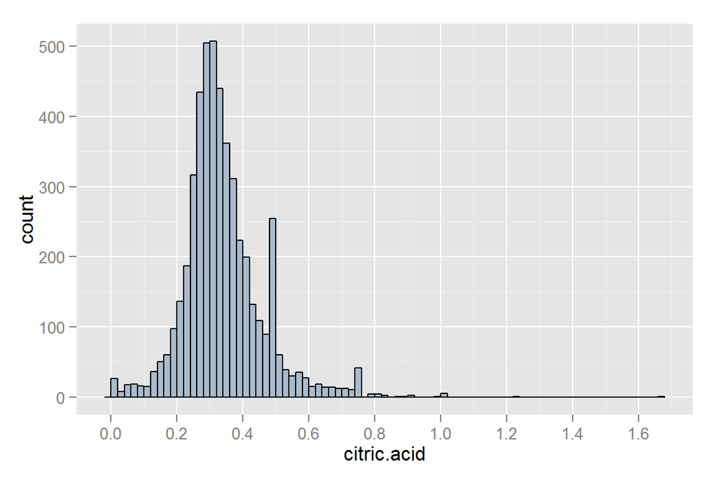

```r
ggplot(aes(citric.acid), data=ww) +
  geom_histogram(binwidth=0.02, color='black', fill='#aabbcc') +
  scale_x_continuous(breaks=seq(0, 2, 0.2))
```

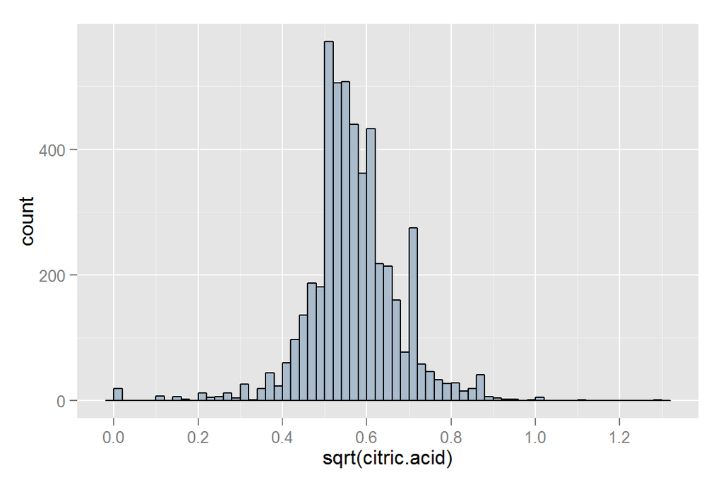

```r
ggplot(aes(sqrt(citric.acid)), data=ww) +
  geom_histogram(binwidth=0.02, color='black', fill='#aabbcc') +
  scale_x_continuous(breaks=seq(0, 2, 0.2))
```

Interestingly, it shows a spike in the right side of the bell-shaped curve (roughly at 0.5 on the first chart). More on it at the analysis section.

### Residual Suagr

```r
summary(ww$residual.sugar)
```

```
##    Min. 1st Qu.  Median    Mean 3rd Qu.    Max.
##   0.600   1.700   5.200   6.391   9.900  65.800
```

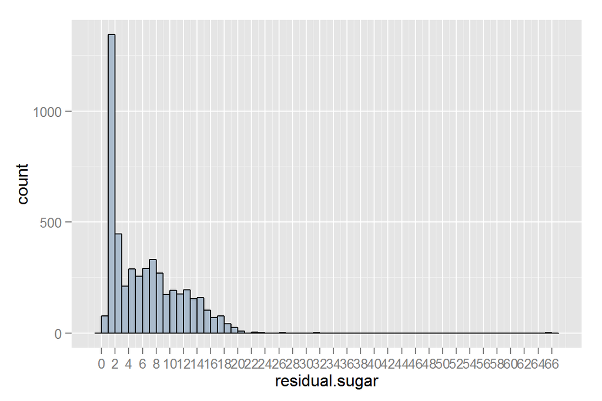

```r
ggplot(aes(residual.sugar), data=ww) +
  geom_histogram(binwidth=1, color='black', fill='#aabbcc') +
  scale_x_continuous(breaks=seq(0, 66, 2))
```

Outlier spotted, let’s remove it.

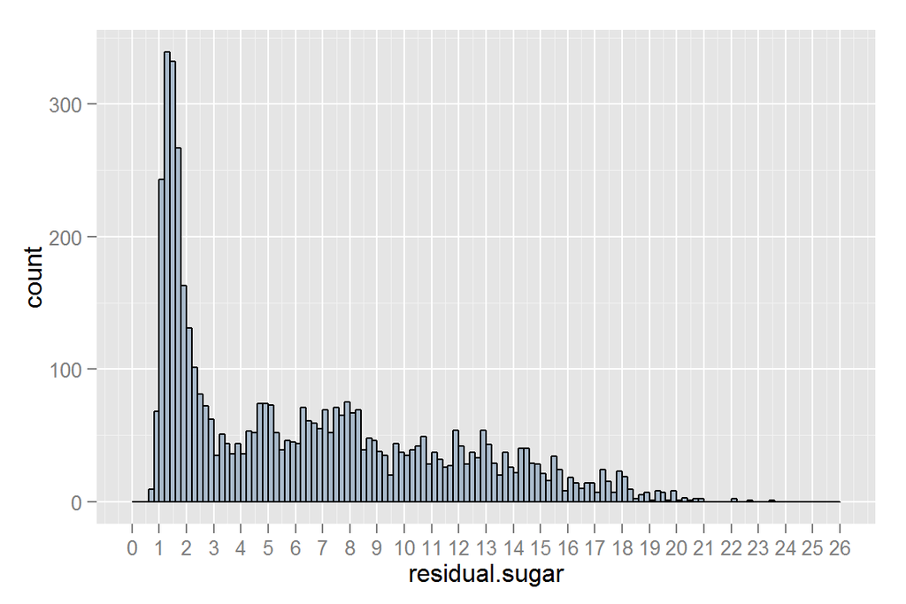

```r
ggplot(aes(residual.sugar), data=ww) +
  geom_histogram(binwidth=0.2, color='black', fill='#aabbcc') +
  scale_x_continuous(breaks=seq(0, 26, 1), limit=c(0,26))
```

The graph is heavily rightly skewed. Let’s modify the scale and see if it reveals any hidden relationships.

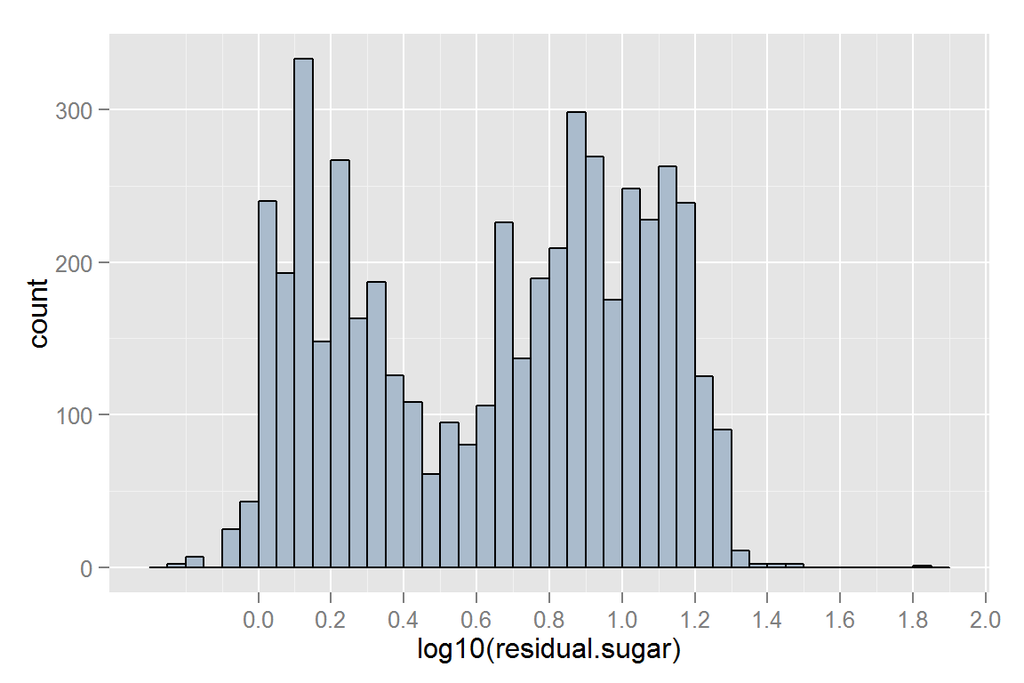

```r
ggplot(aes(log10(residual.sugar)), data=ww) +
  geom_histogram(binwidth=0.05, color='black', fill='#aabbcc') +
  scale_x_continuous(breaks=seq(0, 2, 0.2))
```

It seems to be bi-modal when we take the log scale. More discussion in the analysis section.

### Chlorides

```r
summary(ww$chlorides)
```

```
##    Min. 1st Qu.  Median    Mean 3rd Qu.    Max.
## 0.00900 0.03600 0.04300 0.04577 0.05000 0.34600
```

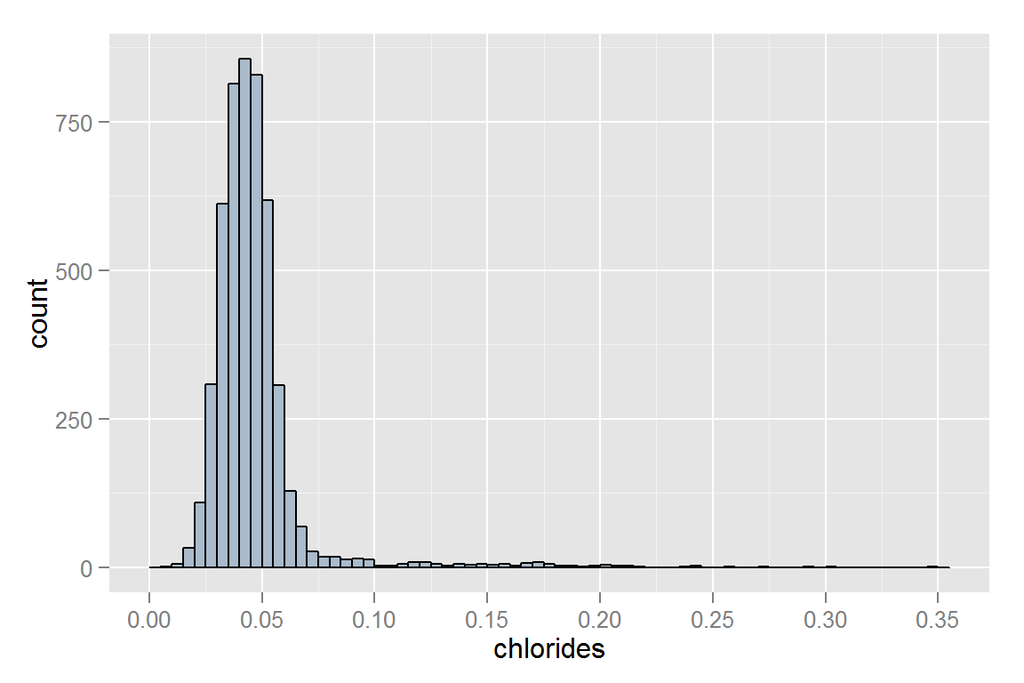

```r
ggplot(aes(chlorides), data=ww) +
  geom_histogram(binwidth=0.005, color='black', fill='#aabbcc') +
  scale_x_continuous(breaks=seq(0, 0.5, 0.05))
```

The graph is bell shape with a tail on the right. Let’s take a look at the log scale.

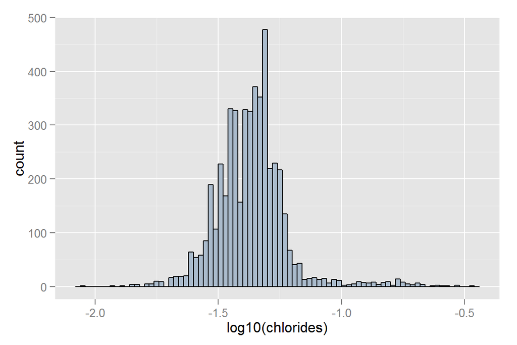

```r
ggplot(aes(log10(chlorides)), data=ww) +
  geom_histogram(binwidth=0.02, color='black', fill='#aabbcc') +
  scale_x_continuous()
```

It doesn’t seem to improve much.

### Free Sulfur Dioxide

```r
summary(ww$free.sulfur.dioxide)
```

```
##    Min. 1st Qu.  Median    Mean 3rd Qu.    Max.
##    2.00   23.00   34.00   35.31   46.00  289.00
```

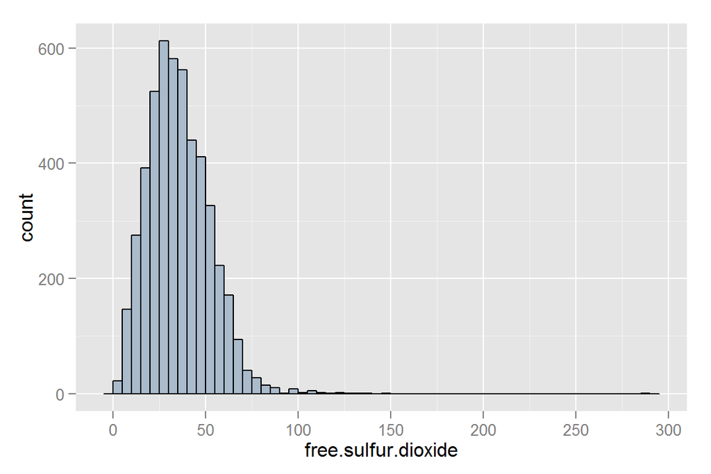

```r
ggplot(aes(free.sulfur.dioxide), data=ww) +
  geom_histogram(binwidth=5, color='black', fill='#aabbcc') +
  scale_x_continuous(breaks=seq(0, 300, 50))
```

Again the graph is with a tail on the right.

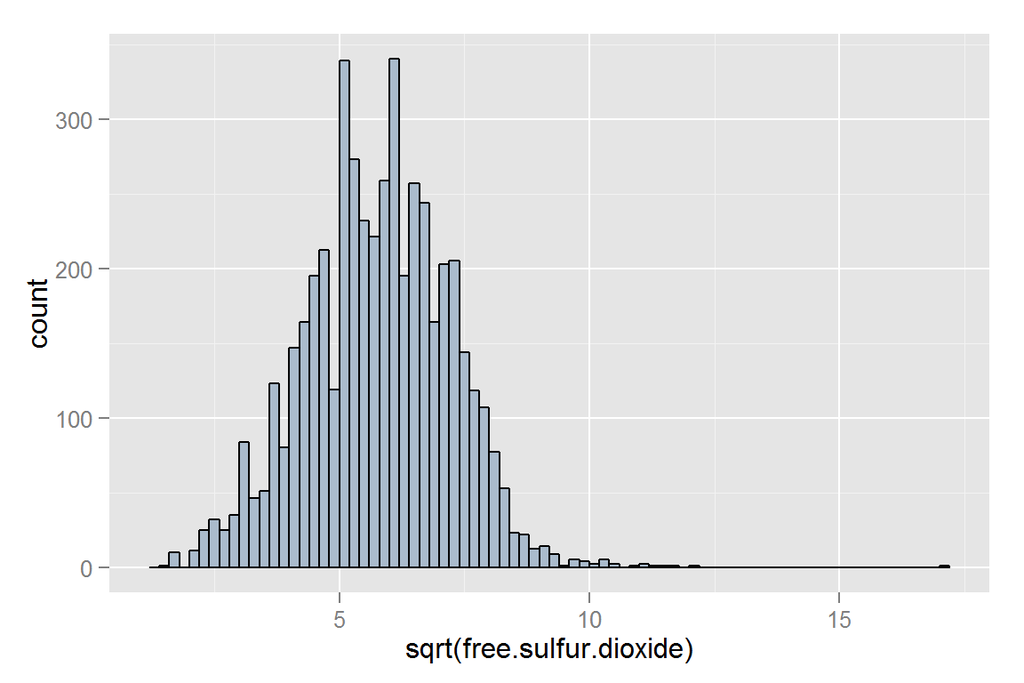

```r
ggplot(aes(sqrt(free.sulfur.dioxide)), data=ww) +
  geom_histogram(binwidth=0.2, color='black', fill='#aabbcc') +
  scale_x_continuous()
```

the sqrt scale doesn’t seem to improve either.

### Total Sulfur Dioxide

```r
summary(ww$total.sulfur.dioxide)
```

```
##    Min. 1st Qu.  Median    Mean 3rd Qu.    Max.
##     9.0   108.0   134.0   138.4   167.0   440.0
```

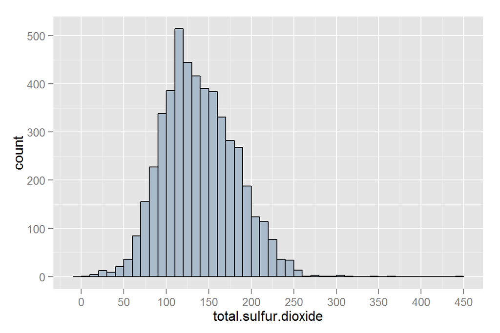

```r
ggplot(aes(total.sulfur.dioxide), data=ww) +
  geom_histogram(binwidth=10, color='black', fill='#aabbcc') +
  scale_x_continuous(breaks=seq(0, 450, 50))
```

It takes a bell shape.

### Density

```r
summary(ww$density)
```

```
##    Min. 1st Qu.  Median    Mean 3rd Qu.    Max.
##  0.9871  0.9917  0.9937  0.9940  0.9961  1.0390
```

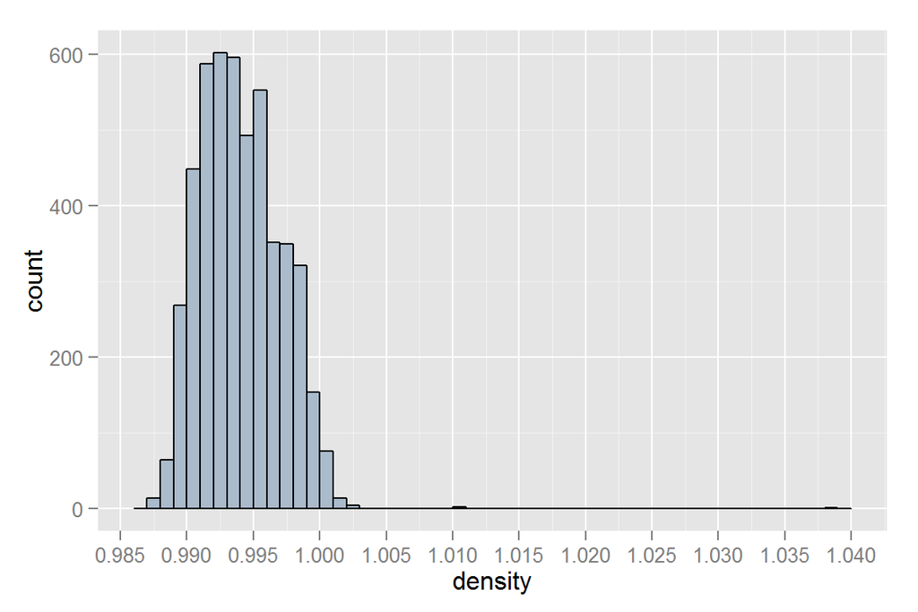

```r
ggplot(aes(density), data=ww) +
  geom_histogram(binwidth=0.001, color='black', fill='#aabbcc') +
  scale_x_continuous(breaks=seq(0, 1.1, 0.005))
```

It more or less takes a bell shape with 2 outliers in the right, and is in general lighter than water.

### pH

```r
summary(ww$pH)
```

```
##    Min. 1st Qu.  Median    Mean 3rd Qu.    Max.
##   2.720   3.090   3.180   3.188   3.280   3.820
```

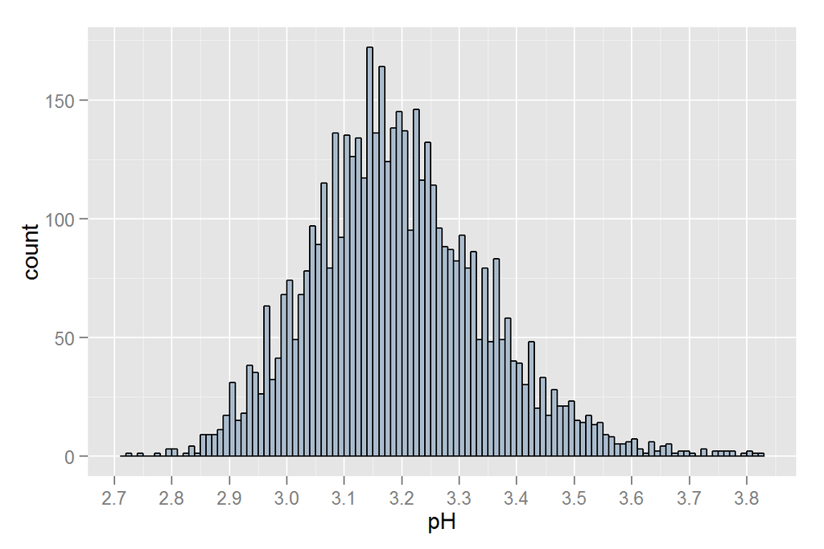

```r
ggplot(aes(pH), data=ww) +
  geom_histogram(binwidth=0.01, color='black', fill='#aabbcc') +
  scale_x_continuous(breaks=seq(0, 4, 0.1))
```

It is somewhat a bell shape but doesn’t sound like normally distributed. They are centered at the acidic region, between 2.7 and 3.8.

### Sulphates

```r
summary(ww$sulphates)
```

```
##    Min. 1st Qu.  Median    Mean 3rd Qu.    Max.
##  0.2200  0.4100  0.4700  0.4898  0.5500  1.0800
```

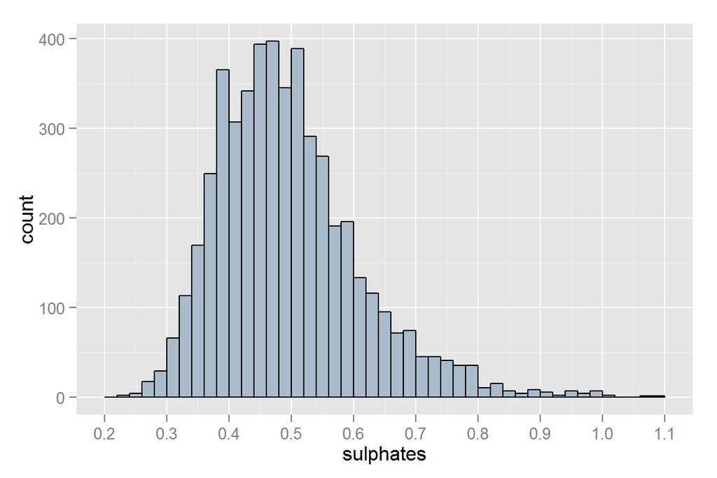

```r
ggplot(aes(sulphates), data=ww) +
  geom_histogram(binwidth=0.02, color='black', fill='#aabbcc') +
  scale_x_continuous(breaks=seq(0, 1.1, 0.1))
```

It is righly skewed.

### Alcohol

```r
summary(ww$alcohol)
```

```
##    Min. 1st Qu.  Median    Mean 3rd Qu.    Max.
##    8.00    9.50   10.40   10.51   11.40   14.20
```

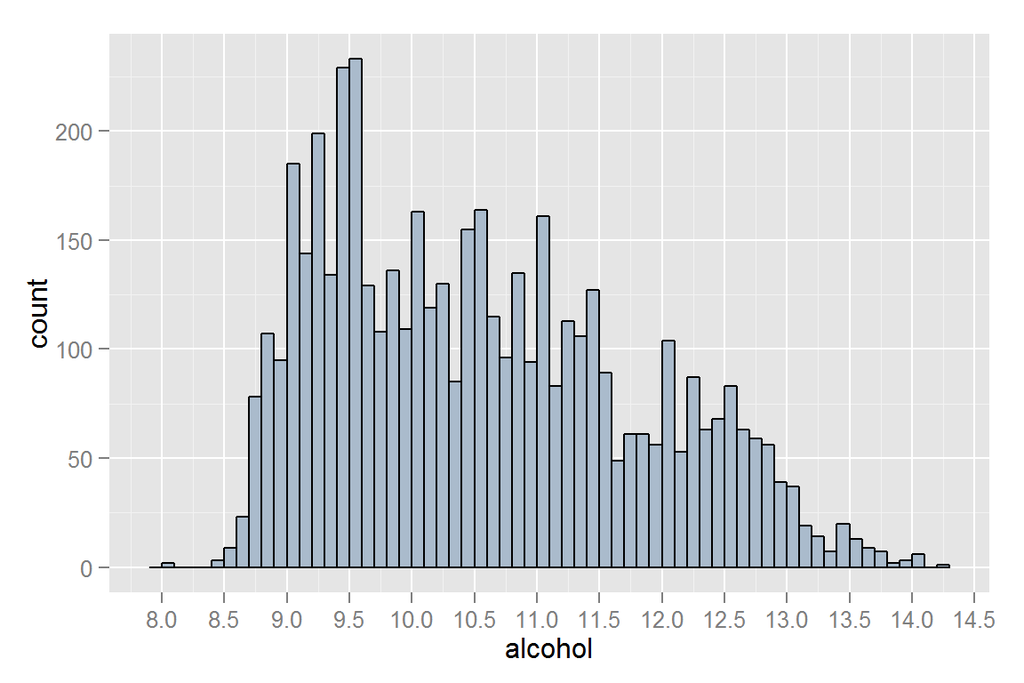

```r
ggplot(aes(alcohol), data=ww) +
  geom_histogram(binwidth=0.1, color='black', fill='#aabbcc') +
  scale_x_continuous(breaks=seq(0, 15, 0.5))
```

Alcohol is an interesting one. It is not bell shape, and there are some spikes in some alcohol % like 10%, 10.5% and 11%. It is more like artificially modified and not following a normal or gaussian distribution. More in the analysis section.

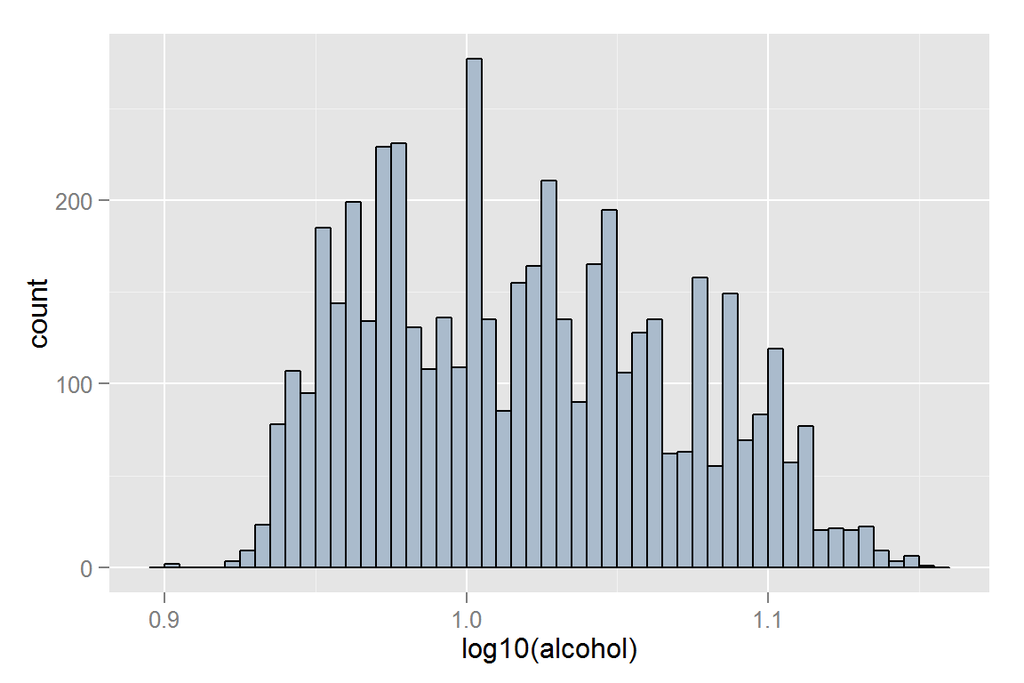

```r
ggplot(aes(log10(alcohol)), data=ww) +
  geom_histogram(binwidth=0.005, color='black', fill='#aabbcc') +
  scale_x_continuous()
```

The log10 scale doesn’t provide more insight though.

### Quality

```r
summary(ww$quality)
```

```
##    Min. 1st Qu.  Median    Mean 3rd Qu.    Max.
##   3.000   5.000   6.000   5.878   6.000   9.000
```

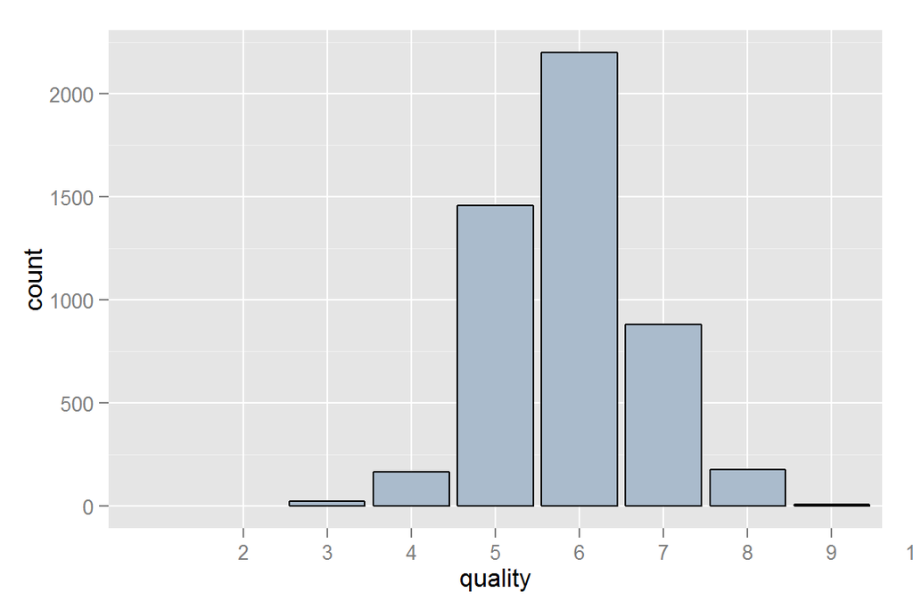

```r
ggplot(aes(quality), data=ww) +
  geom_histogram(binwidth=1, color='black', fill='#aabbcc') +
  scale_x_discrete(breaks=seq(0, 10, 1))
```

So the ratings run from 3 to 9, with 6 being the mode.

# Univariate Analysis

### What is the structure of your dataset?

In this dataset we have 4898 observations with 13 variables, one of them (X) being the unique identifier, one of them (quality) is a factor (or discrete integer in the dataset) which span from 0 to 10 with 10 the best, and the rest are continuous vectors which are the chemicals in the white wines.

Looking at the acidity (pH), most of white wines are around 3.0 - 3.3 which is acidic.

Most vectors are in a typical bell shape, but some of them are rightly skewed.

### Of the features you investigated, were there any unusual distributions? Did you perform any operations on the data to tidy, adjust, or change the form of the data? If so, why did you do this?

In some of the rightly skewed vectors, there seem to be outliers: citric.acid, residual.sugar, chlorides, free.sulfur.dioxide, & alcohol. So we have tried some transformations (squre root, log10, etc.) in these histograms to see if we can achieve a more bell-shape curve above. For density, the histogram is in typical bell shape but with a couple of outliers.

Interestingly, taking a log scale of residual.sugar created a bi-modal histogram. Since people perceive sweetness in similar scale, it might indicate that there are 2 sweetness levels of white wine preferred in the market.

For residual.suagr, since >45g/L is considered “sweet”, there seems to be an outlier in the dataset:

```r
summary(ww$residual.sugar>45)
```

```
##    Mode   FALSE    TRUE    NA's
## logical    4897       1       0
```

But perhaps extra sugar was intentionally added for a specific market niche. We cannot confirm whether this data point is indeed invalid.

For alocohol, even taking a log scale to plot doesn’t create a bell shape histogram. It is probably due to the fact that they are artificially tuned to a whole number (or in the whole decimal point) when bottled. It can be confirmed by tabling it:

```r
table(ww$alcohol)
```

```
##
##                8              8.4              8.5              8.6
##                2                3                9               23
##              8.7              8.8              8.9                9
##               78              107               95              185
##              9.1              9.2              9.3              9.4
##              144              199              134              229
##              9.5 9.53333333333333             9.55              9.6
##              228                3                2              128
## 9.63333333333333              9.7 9.73333333333333             9.75
##                1              105                2                1
##              9.8              9.9               10 10.0333333333333
##              136              109              162                1
##             10.1 10.1333333333333            10.15             10.2
##              114                2                3              130
##             10.3             10.4 10.4666666666667             10.5
##               85              153                2              160
## 10.5333333333333            10.55 10.5666666666667             10.6
##                1                2                1              114
##            10.65             10.7             10.8             10.9
##                1               96              135               88
## 10.9333333333333 10.9666666666667            10.98               11
##                2                3                1              158
##            11.05 11.0666666666667             11.1             11.2
##                2                1               83              112
## 11.2666666666667             11.3 11.3333333333333            11.35
##                1              101                3                1
## 11.3666666666667             11.4 11.4333333333333            11.45
##                1              121                1                4
## 11.4666666666667             11.5            11.55             11.6
##                1               88                1               46
## 11.6333333333333            11.65             11.7 11.7333333333333
##                2                1               58                1
##            11.75             11.8            11.85             11.9
##                2               60                1               53
##            11.94            11.95               12            12.05
##                2                1              102                1
## 12.0666666666667             12.1            12.15             12.2
##                1               51                2               86
##            12.25             12.3 12.3333333333333             12.4
##                1               62                1               68
##             12.5             12.6             12.7            12.75
##               83               63               56                3
##             12.8 12.8933333333333             12.9               13
##               54                2               39               36
##            13.05             13.1 13.1333333333333             13.2
##                1               18                1               14
##             13.3             13.4             13.5            13.55
##                7               20               12                1
##             13.6             13.7             13.8             13.9
##                9                7                2                3
##               14            14.05             14.2
##                5                1                1
```

There are a lot more observations in like, 11 to 11.05.

One interesting observation in the plots is that citric.acid has a spike in the bin 0.48-0.5. If we look at it closely, it happens at 0.49.

```r
table(ww$citric.acid)
```

```
##
##    0 0.01 0.02 0.03 0.04 0.05 0.06 0.07 0.08 0.09  0.1 0.11 0.12 0.13 0.14
##   19    7    6    2   12    5    6   12    4   12   14    1   19   17   27
## 0.15 0.16 0.17 0.18 0.19  0.2 0.21 0.22 0.23 0.24 0.25 0.26 0.27 0.28 0.29
##   23   33   27   49   48   70   66  104   83  181  136  219  216  282  223
##  0.3 0.31 0.32 0.33 0.34 0.35 0.36 0.37 0.38 0.39  0.4 0.41 0.42 0.43 0.44
##  307  200  257  183  225  137  177  134  122  101  117   82   95   37   63
## 0.45 0.46 0.47 0.48 0.49  0.5 0.51 0.52 0.53 0.54 0.55 0.56 0.57 0.58 0.59
##   46   51   38   39  215   35   25   23   16   19   11   22   13   21    6
##  0.6 0.61 0.62 0.63 0.64 0.65 0.66 0.67 0.68 0.69  0.7 0.71 0.72 0.73 0.74
##    6    9   14    4    6    8    7    7    7    5    3    9    5    5   41
## 0.78 0.79  0.8 0.81 0.82 0.86 0.88 0.91 0.99    1 1.23 1.66
##    2    2    2    2    2    1    1    2    1    5    1    1
```

It seems that this is artificially added to the wine to acidify it or remove excess iron and copper from the wine if potassium ferrocyanide is not available. (source: http://en.wikipedia.org/wiki/Acids_in_wine)

### What is/are the main feature(s) of interest in your dataset?

Of course we’d like to know which chemicals/attributes contribute to the perceived quality of the white wine. So we will do more analysis in the subsequent bivariate sections to find the relationships between quality and these chemicals/attributes.

### What other features in the dataset do you think will help support your investigation into your feature(s) of interest?

Honestly, it is really hard to tell which will prevail by only looking at the univariate plots.

### Did you create any new variables from existing variables in the dataset?

Since saltiness might cancel out sweetness, in straight sense, we might want to measure sweetness not only by residual sugar but its abundance, or proportion, against salt in the liquid. So we added one variable called “sweetness” to measure this.

### Sweetness

```r
ww$sweetness <- ww$residual.sugar/ww$chlorides
summary(ww$sweetness)
```

```
##    Min. 1st Qu.  Median    Mean 3rd Qu.    Max.
##   4.324  43.950 126.600 148.500 232.100 889.200
```

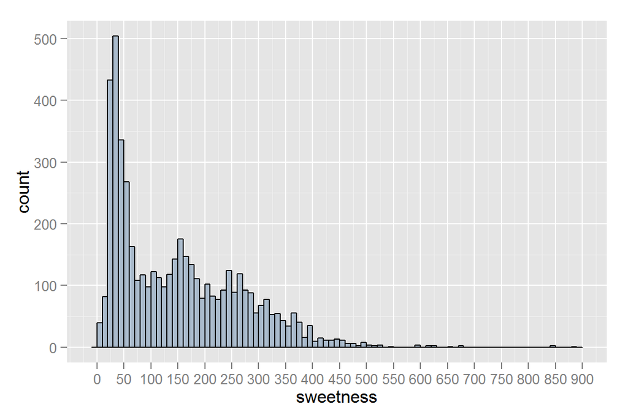

```r
ggplot(aes(sweetness), data=ww) +
  geom_histogram(binwidth=10, color='black', fill='#aabbcc') +
  scale_x_continuous(breaks=seq(0, 900, 50))
```

It shows more or less like the distribution of residual sugar.

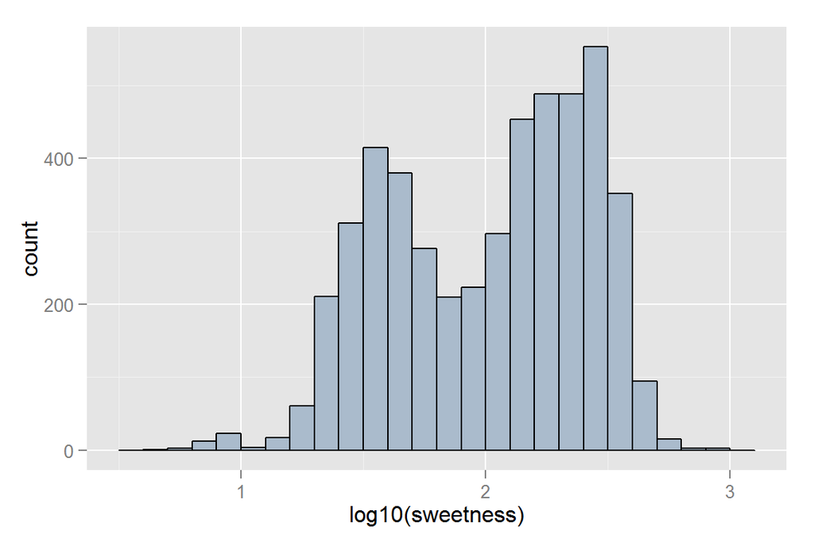

```r
ggplot(aes(log10(sweetness)), data=ww) +
  geom_histogram(binwidth=0.1, color='black', fill='#aabbcc') +
  scale_x_continuous()
```

Again like residual sugar, it seems to be bi-modal.

Finally, we added one more vector called quality.f which is exactly the same as quality but processed as factor in R.

```r
ww$quality.f <- as.factor(ww$quality)
```

# Bivariate Plots Section

We first do a plot matrix to get a feel of the dataset. (The result is in Rplot.pdf attached)

```
install.packages("GGally")
library(GGally)
theme_set(theme_minimal(20))

set.seed(1836)
ww_subset <- ww[, c(2:15)]
names(ww_subset)
ggpairs(ww_subset[sample.int(nrow(ww_subset), 1000), ],
        axisLabels='internal',
        lower = list(continuous = "points", combo = "box"))
```

We can immediately spot some relationships. The top absolute correlations (positive or negative) are:

1. sweetness & residual.sugar - 0.91 (pretty obvious, huh?)
2. residual.sugar & density - 0.828
3. alcohol & density - 0.795
4. sweetness & density - 0.662
5. free.sulfur.dioxide & total.sulfur.dioxide - 0.615 (again obvious)

More on the above in the Multivariate Analysis section. Now let’s take a closer look at how these variables affect quality, which is the attribute we’re most interested, through box plots.

### Quality on All Variables

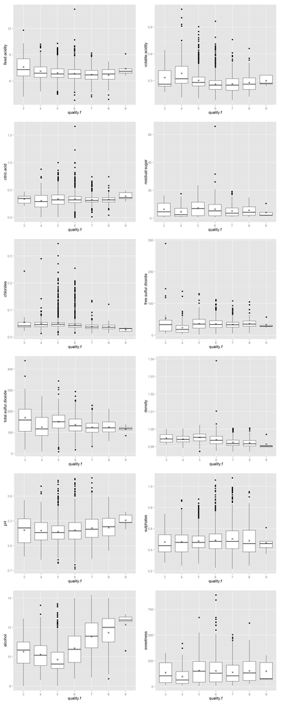

```r
bp1 <- ggplot(aes(quality.f, fixed.acidity),data=ww) +
  geom_boxplot() +
  stat_summary(fun.y = mean, geom='point', shape=4)
bp2 <- ggplot(aes(quality.f, volatile.acidity),data=ww) +
  geom_boxplot() +
  stat_summary(fun.y = mean, geom='point', shape=4)
bp3 <- ggplot(aes(quality.f, citric.acid),data=ww) +
  geom_boxplot() +
  stat_summary(fun.y = mean, geom='point', shape=4)
bp4 <- ggplot(aes(quality.f, residual.sugar),data=ww) +
  geom_boxplot() +
  stat_summary(fun.y = mean, geom='point', shape=4)
bp5 <- ggplot(aes(quality.f, chlorides),data=ww) +
  geom_boxplot() +
  stat_summary(fun.y = mean, geom='point', shape=4)
bp6 <- ggplot(aes(quality.f, free.sulfur.dioxide),data=ww) +
  geom_boxplot() +
  stat_summary(fun.y = mean, geom='point', shape=4)
bp7 <- ggplot(aes(quality.f, total.sulfur.dioxide),data=ww) +
  geom_boxplot() +
  stat_summary(fun.y = mean, geom='point', shape=4)
bp8 <- ggplot(aes(quality.f, density),data=ww) +
  geom_boxplot() +
  stat_summary(fun.y = mean, geom='point', shape=4)
bp9 <- ggplot(aes(quality.f, pH),data=ww) +
  geom_boxplot() +
  stat_summary(fun.y = mean, geom='point', shape=4)
bp10 <- ggplot(aes(quality.f, sulphates),data=ww) +
  geom_boxplot() +
  stat_summary(fun.y = mean, geom='point', shape=4)
bp11 <- ggplot(aes(quality.f, alcohol),data=ww) +
  geom_boxplot() +
  stat_summary(fun.y = mean, geom='point', shape=4)
bp12 <- ggplot(aes(quality.f, sweetness),data=ww) +
  geom_boxplot() +
  stat_summary(fun.y = mean, geom='point', shape=4)
grid.arrange(bp1,bp2,bp3,bp4,bp5,bp6,
             bp7,bp8,bp9,bp10,bp11,bp12,ncol=2)
```

Added to the correlations shown in the Rplot.pdf, it seems that only alcohol has a stronger trend showing some effect on quality. There are milder trends for like density too. Let’s take a closer look in the next section for them.

# Bivariate Analysis

### Talk about some of the relationships you observed in this part of the investigation. How did the feature(s) of interest vary with other features in the dataset?

By looking at the boxplots against quality above, we can observe a relatively stronger trend on the plot with alcohol compared to others. Density comes into next although it is less obvious.

### Quality on Density

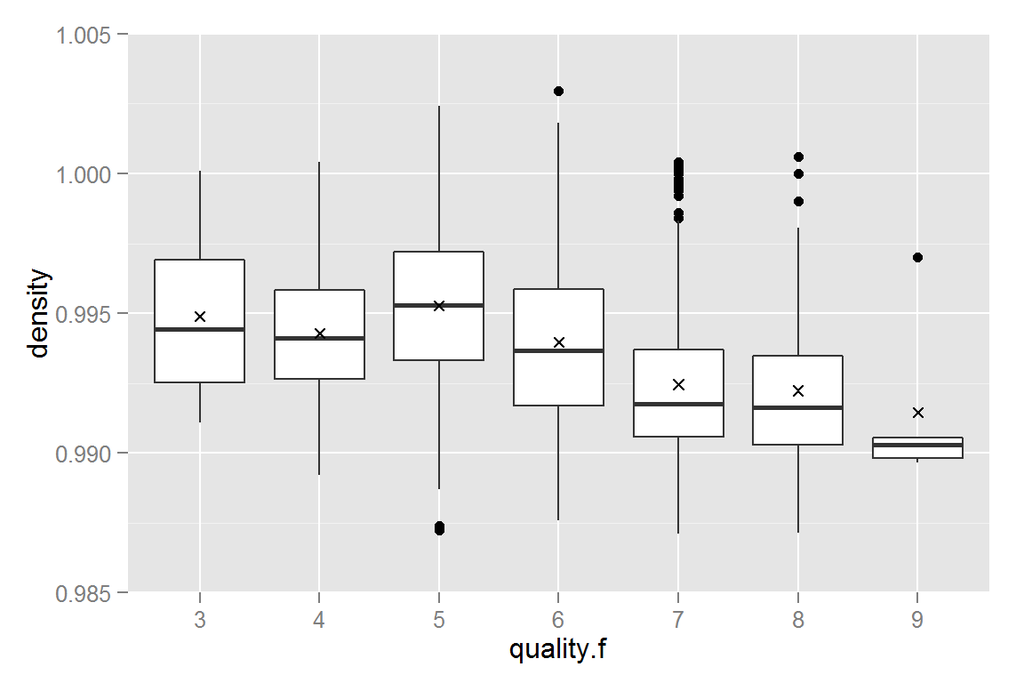

```r
bp8 + coord_cartesian(ylim=c(0.985, 1.005))
```

Quality in general goes higher when density gets lower.

### Quality on Alcohol

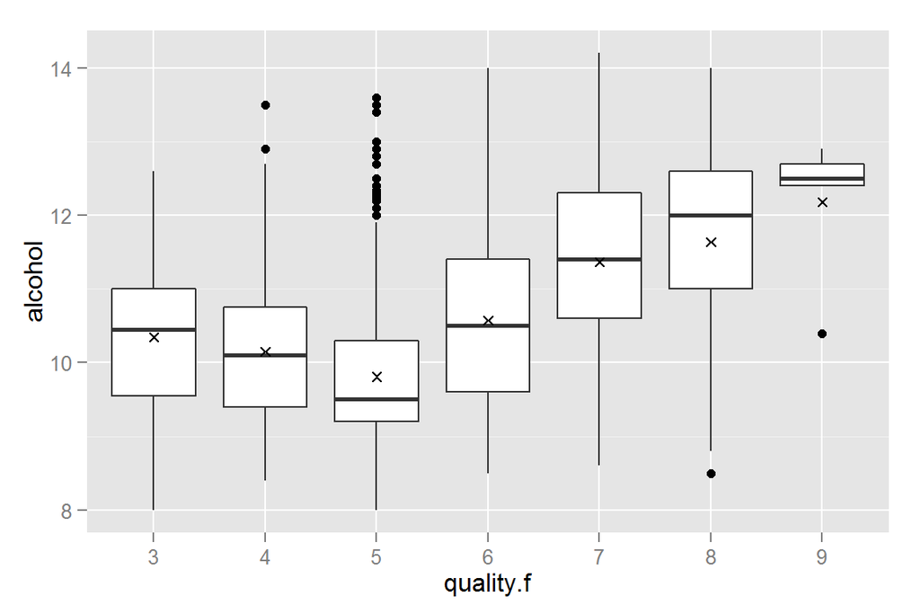

```r
bp11
```

Quality in general goes higher when alcohol % gets higher.

For other variables, there are no strong correlations spotted. But on the safe side, let’s take other scales for those variables which aren’t in bell shape and see if a different scale will produce different results:

### Square Root of Citric Acid

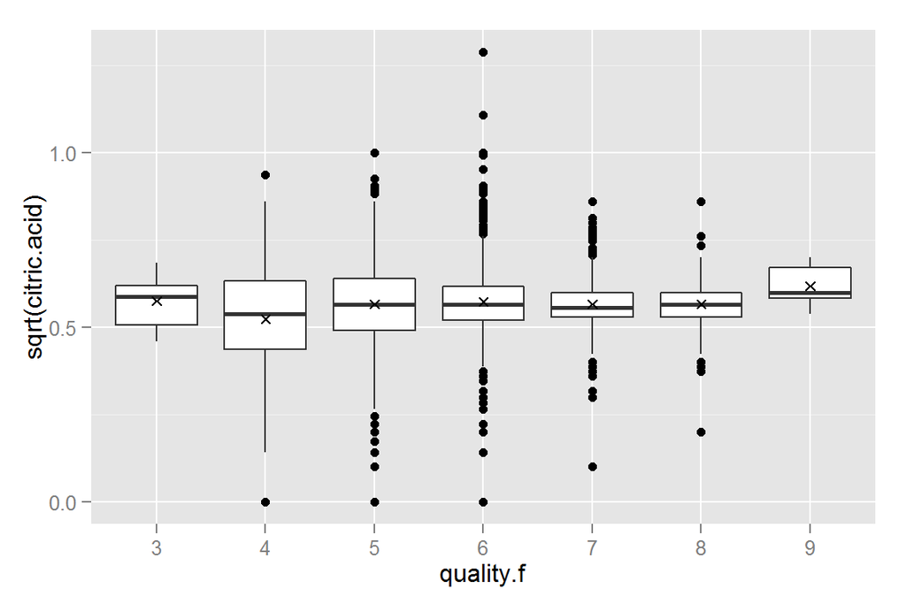

```r
ggplot(aes(quality.f, sqrt(citric.acid)), data=ww) +
  geom_boxplot() +
  stat_summary(fun.y = mean, geom='point', shape=4)
```

Quality doesn’t appear to have relationship even with square root of Citric Acid.

### Log10 of Residual Sugar

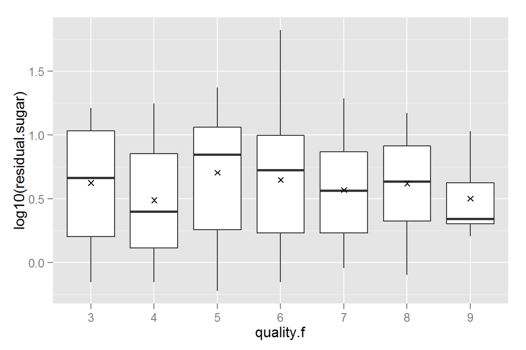

```r
ggplot(aes(quality.f, log10(residual.sugar)), data=ww) +
  geom_boxplot() +
  stat_summary(fun.y = mean, geom='point', shape=4)
```

Quality doesn’t appear to have relationship even with log10 of Residual Sugar.

### Log10 of Chlorides

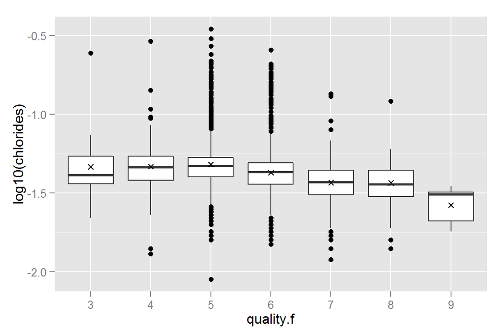

```r
ggplot(aes(quality.f, log10(chlorides)), data=ww) +
  geom_boxplot() +
  stat_summary(fun.y = mean, geom='point', shape=4)
```

There seems mild trend of Quality’s relationship with log10 of Chlorides. Let’s look at the correlation:

```r
cor.test(ww$quality,ww$chlorides)
```

```
##
##  Pearson's product-moment correlation
##
## data:  ww$quality and ww$chlorides
## t = -15.024, df = 4896, p-value < 2.2e-16
## alternative hypothesis: true correlation is not equal to 0
## 95 percent confidence interval:
##  -0.2365501 -0.1830039
## sample estimates:
##        cor
## -0.2099344
```

So chlorides don’t affect quality much from the correlation itself.

### Square Root of Free Sulfur Dioxide

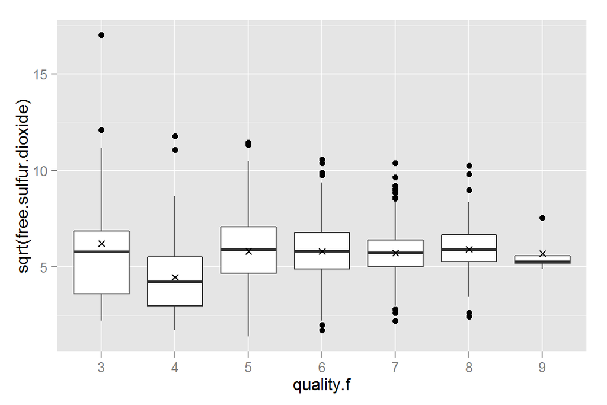

```r
ggplot(aes(quality.f, sqrt(free.sulfur.dioxide)), data=ww) +
  geom_boxplot() +
  stat_summary(fun.y = mean, geom='point', shape=4)
```

Quality doesn’t appear to have relationship even with square root of Free Sulfur Dioxide.

### Did you observe any interesting relationships between the other features (not the main feature(s) of interest)?

Obviously, sweetness is positively correlated to residual.sugar (r = 0.91). Except that, density is correlated to residual.sugar and alcohol, while free.sulfur.oxide is correlated to total.sulfur.dioxide.

### What was the strongest relationship you found?

Except those less interested one, quality correlates the most to alcohol (r = 0.464, please refer to the plot matrix). Next in line is density (r = -0.328). Others are too close to zero to claim correlations.

# Multivariate Plots Section

We have spotted several high correlations between a couple of variables above. To reiterate:

1. sweetness & residual.sugar - 0.91 (pretty obvious, huh?)
2. residual.sugar & density - 0.828
3. alcohol & density - 0.795
4. sweetness & density - 0.662
5. free.sulfur.dioxide & total.sulfur.dioxide - 0.615 (again obvious)

Let’s take a closer look on them. And additionally, since we are interested in how they affects quality too, we will color the scatter plots with quality.

### Residual Sugar & Sweetness

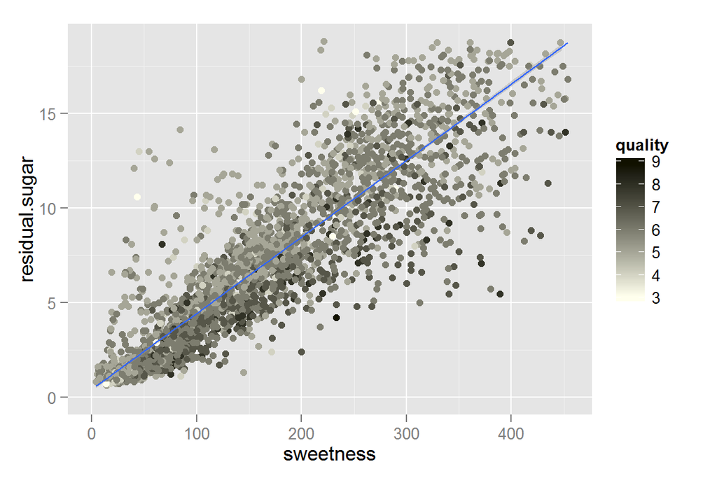

```r
ggplot(aes(sweetness, residual.sugar), data=ww) +
  geom_point(aes(color=quality)) +
  scale_x_continuous(limits=c(0, quantile(ww$sweetness, 0.99))) +
  scale_y_continuous(limits=c(0, quantile(ww$residual.sugar, 0.99))) +
  scale_color_gradient(high='#111100', low='#ffffee') +
  stat_smooth(method="lm")
```

```r
cor.test(ww$sweetness,ww$residual.sugar)
```

```
##
##  Pearson's product-moment correlation
##
## data:  ww$sweetness and ww$residual.sugar
## t = 155.02, df = 4896, p-value < 2.2e-16
## alternative hypothesis: true correlation is not equal to 0
## 95 percent confidence interval:
##  0.9065845 0.9160715
## sample estimates:
##       cor
## 0.9114491
```

As stated above, sweetness is obviously correlated to residual sugar and produce a strong correlation (r = 0.911). This graph doesn’t show a clear pattern for quality though, so it might indicate that quality isn’t determined by residual sugar, or sweetness.

### Residual Sugar & Density

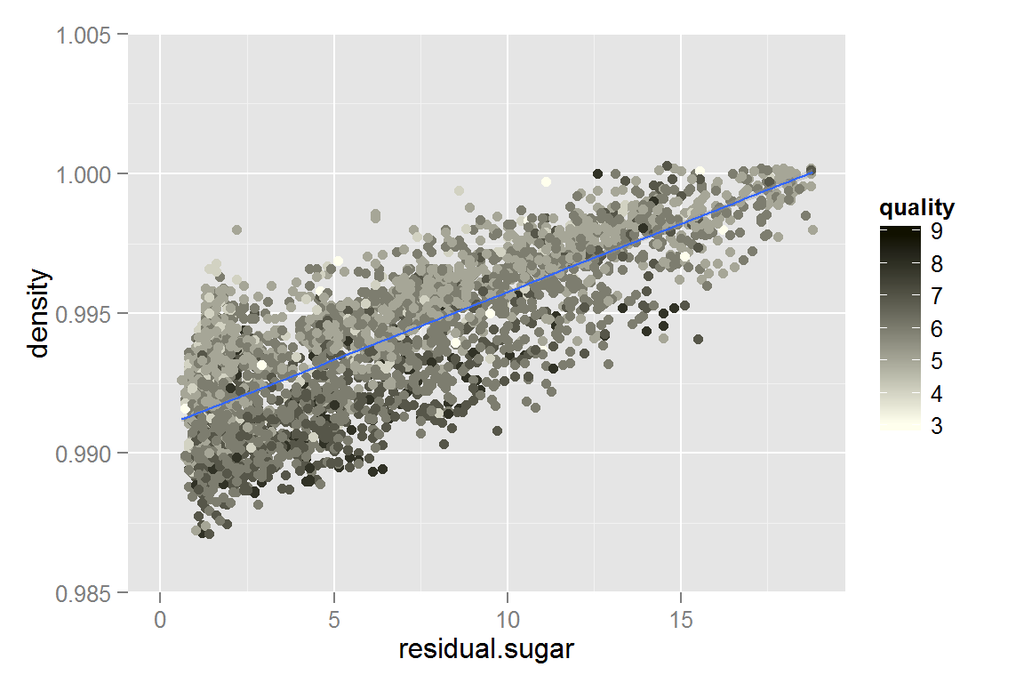

```r
ggplot(aes(residual.sugar, density), data=ww) +
  geom_point(aes(color=quality)) +
  coord_cartesian(ylim=c(0.985, 1.005)) +
  scale_x_continuous(limits=c(0, quantile(ww$residual.sugar, 0.99))) +
  scale_y_continuous(limits=c(0, quantile(ww$density, 0.99))) +
  scale_color_gradient(high='#111100', low='#ffffee') +
  stat_smooth(method="lm")
```

```r
cor.test(ww$residual.sugar,ww$density)
```

```
##
##  Pearson's product-moment correlation
##
## data:  ww$residual.sugar and ww$density
## t = 107.87, df = 4896, p-value < 2.2e-16
## alternative hypothesis: true correlation is not equal to 0
## 95 percent confidence interval:
##  0.8304732 0.8470698
## sample estimates:
##       cor
## 0.8389665
```

### Density & Sweetness

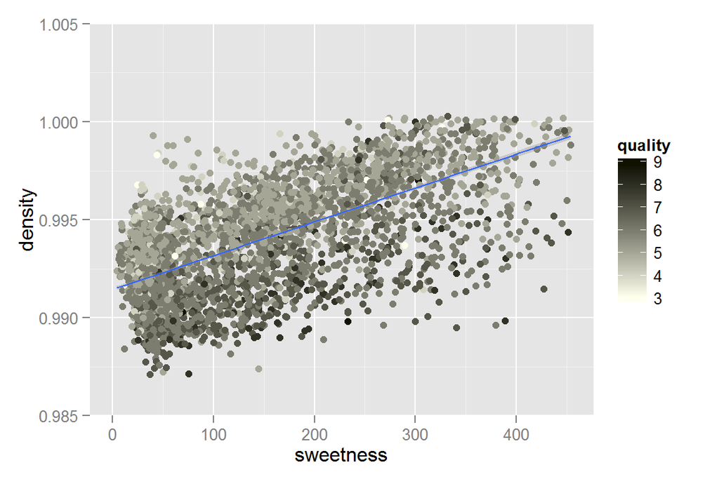

```r
ggplot(aes(sweetness, density), data=ww) +
  geom_point(aes(color=quality)) +
  coord_cartesian(ylim=c(0.985, 1.005)) +
  scale_x_continuous(limits=c(0, quantile(ww$sweetness, 0.99))) +
  scale_y_continuous(limits=c(0, quantile(ww$density, 0.99))) +
  scale_color_gradient(high='#111100', low='#ffffee') +
  stat_smooth(method="lm")
```

```r
cor.test(ww$sweetness,ww$density)
```

```
##
##  Pearson's product-moment correlation
##
## data:  ww$sweetness and ww$density
## t = 63.548, df = 4896, p-value < 2.2e-16
## alternative hypothesis: true correlation is not equal to 0
## 95 percent confidence interval:
##  0.6566680 0.6873739
## sample estimates:
##       cor
## 0.6723101
```

### Free Sulfur Dioxide & Total Sulfur Dioxide

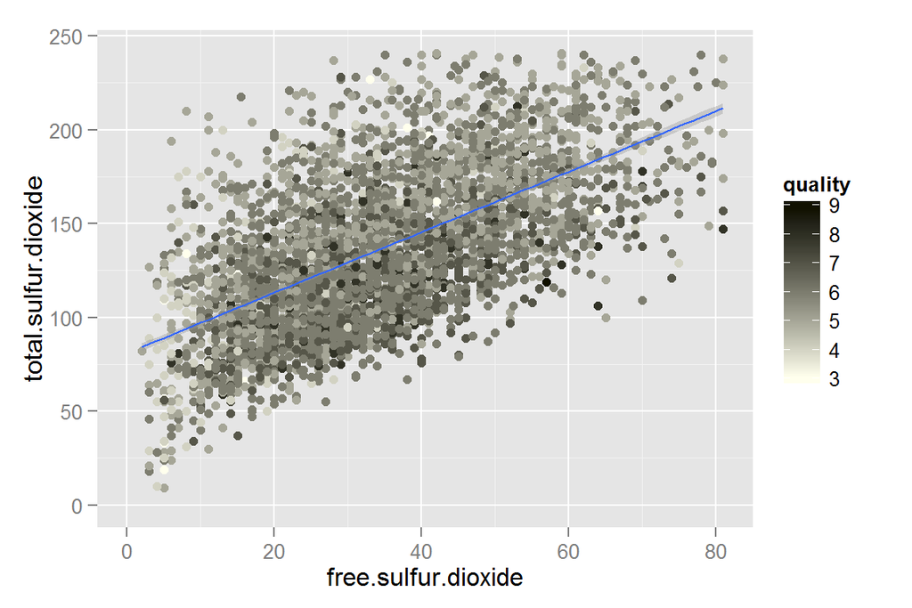

```r
ggplot(aes(free.sulfur.dioxide, total.sulfur.dioxide), data=ww) +
  geom_point(aes(color=quality)) +
  scale_x_continuous(limits=c(0, quantile(ww$free.sulfur.dioxide, 0.99))) +
  scale_y_continuous(limits=c(0, quantile(ww$total.sulfur.dioxide, 0.99))) +
  scale_color_gradient(high='#111100', low='#ffffee') +
  stat_smooth(method="lm")
```

```r
cor.test(ww$free.sulfur.dioxide,ww$total.sulfur.dioxide)
```

```
##
##  Pearson's product-moment correlation
##
## data:  ww$free.sulfur.dioxide and ww$total.sulfur.dioxide
## t = 54.645, df = 4896, p-value < 2.2e-16
## alternative hypothesis: true correlation is not equal to 0
## 95 percent confidence interval:
##  0.5977994 0.6326026
## sample estimates:
##      cor
## 0.615501
```

Pretty obviously, free sulfur dioxide correlates with total sulfur dioxide (r = 0.61). It doesn’t do anything with quality though.